# Movie Data Analysis

Pulkit Mathur

November 30, 2018

### 1005483692

### Data Collection

#### 1) NewYork Times data-

| display_title | mpaa_rating | critics_pick | byline | headline | summary_short | publication_date | opening_date | date_updated | link.type | link.url | link.suggested_link_text | multimedia.type | multimedia.src | multimedia.width | multimedia.height |
| --- | --- | --- | --- | --- | --- | --- | --- | --- | --- | --- | --- | --- | --- | --- | --- |
| The Spy Who Dumped Me | R | 0 | A.O. SCOTT | Review: ‘The Spy Who Dumped Me’ Is a Buddy Comedy With a Body Count | Mila Kunis and Kate McKinnon are best friends who help each other through emotional and geopolitical chaos in this silly, bloody movie. | 2018-08-01 | 2018-08-03 | 2018-09-01 16:44:01 | article | http://www.nytimes.com/2018/08/01/movies/the-spy-who-dumped-me-review.html | Read the New York Times Review of The Spy Who Dumped Me | mediumThreeByTwo210 | https://static01.nyt.com/images/2018/08/03/movies/03spywhodumped1/03spywhodumped1-mediumThreeByTwo210.jpg | 210 | 140 |

#### 2) OMDb Data

| Title | Year | Rated | Released | Runtime | Genre | Director | Writer | Actors | Plot | Language | Country | Awards | Poster | Ratings.Source | Ratings.Value | Ratings.Source.1 | Ratings.Value.1 | Ratings.Source.2 | Ratings.Value.2 | Metascore | imdbRating | imdbVotes | imdbID | Type | DVD | BoxOffice | Production | Website | Response |
| --- | --- | --- | --- | --- | --- | --- | --- | --- | --- | --- | --- | --- | --- | --- | --- | --- | --- | --- | --- | --- | --- | --- | --- | --- | --- | --- | --- | --- | --- |
| The Spy Who Dumped Me | 2018 | R | 03 Aug 2018 | 117 min | Action, Adventure, Comedy | Susanna Fogel | Susanna Fogel, David Iserson | Justin Theroux, Blanka Györfi-Tóth, Vilma Szécsi, Mila Kunis | Audrey and Morgan are best friends who unwittingly become entangled in an international conspiracy when one of the women discovers the boyfriend who dumped her was actually a spy. | English, Russian, French | USA, Canada | N/A | https://m.media-amazon.com/images/M/MV5BNDY1MTA0NjgyN15BMl5BanBnXkFtZTgwMTEzNDQ4NTM@._V1_SX300.jpg | Internet Movie Database | 6.2/10 | Rotten Tomatoes | 50% | Metacritic | 52/100 | 52 | 6.2 | 15,262 | tt6663582 | movie | 16 Oct 2018 | N/A | Lionsgate | https://www.thespywhodumpedme.movie/ | True |

| movie | distributor | gross | percent_change | theaters | per_theater | total_gross | days | date |
| --- | --- | --- | --- | --- | --- | --- | --- | --- |
| Stuart Little | Sony Pictures | 6762000 | 34 | 2898 | 2333 | 75636000 | 16 | 2000-01-01 |
| Any Given Sunday | Warner Bros. | 6209000 | 195 | 2505 | 2479 | 42510000 | 11 | 2000-01-01 |
| The Talented Mr. Ripley | Paramount Pictures | 6136000 | 181 | 2310 | 2656 | 35599000 | 8 | 2000-01-01 |
| The Green Mile | Warner Bros. | 5849000 | 126 | 2878 | 2032 | 73343000 | 23 | 2000-01-01 |
| Toy Story 2 | Walt Disney | 5143000 | 46 | 3105 | 1656 | 205019000 | 44 | 2000-01-01 |
| Galaxy Quest | Dreamworks SKG | 4564000 | 94 | 2445 | 1867 | 24475000 | 8 | 2000-01-01 |

Above data has been fetched from “THE NUMBERS”" website

Number of rows-

```
## [1] 209272
```

#### Data Cleaning

In the Boxoffice data we have revenue data for movie daywise, but number of days are not common for every movie

For example, movie A has revenue data for first 16 days while another movie B has revenue data for 23 days.

To solve this disparity,

1. We will deal with only first 10 days revenue data for each movie and remove rest of the rows.

Number of rows left-

```
## [1] 34765
```

2. We will remove movies that have only partial data for first 10 days revenue

Number of rows left-

```
## [1] 31110
```

For question1 and question2 data is sampled in following manner-

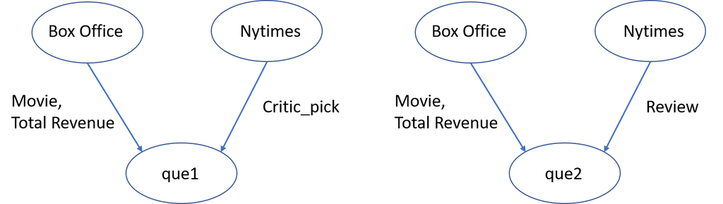

Figure1: Que1-How well do New York Times (NYT) movie critics pick box office hits? ,Que2-Is there a relationship between NYT movie review sentiment and crtics picks?

Data looks like this

| movie | total_gross | Critic_Pick | BoxOffice_Hit | Review_url |
| --- | --- | --- | --- | --- |
| Black Panther | 403613257 | 1 | 1 | http://www.nytimes.com/2018/02/06/movies/black-panther-review-movie.html |
| The Avengers | 373071647 | 0 | 1 | http://www.nytimes.com/2012/05/04/movies/robert-downey-jr-in-the-avengers-directed-by-joss-whedon.html |
| Rogue One: A Star Wars Story | 286033442 | 0 | 1 | http://www.nytimes.com/2016/12/13/movies/star-wars-rogue-one-review.html |
| Iron Man 3 | 284946699 | 0 | 1 | http://www.nytimes.com/2013/05/03/movies/iron-man-3-with-robert-downey-jr.html |
| Jurassic World: Fallen Kingdom | 265699530 | 0 | 1 | http://www.nytimes.com/2018/06/20/movies/jurassic-world-fallen-kingdom-review-chris-pratt.html |
| Furious 7 | 251516400 | 0 | 1 | http://www.nytimes.com/2015/04/03/movies/review-in-furious-7-a-franchise-continues-to-roar.html |

further review data can be scraped from web pages with the help of url

For example review of movie “Black Panther” can be scraped with following sample code

```r
url = as.character(movie_data[1,'Review_url'])
webpage <- read_html(url)
data <- html_nodes(webpage,'.e2kc3sl0')
data <- html_text(data)
if(length(data)==0){
  data <- html_nodes(webpage,'.story-content')
  data <- html_text(data)
}
if(length(data)!=0){
  review = ""
  for (para in data){
    review = paste(review,para)
  }
  review = data_frame(text = review)
}
```

for question3 data is sampled via following way

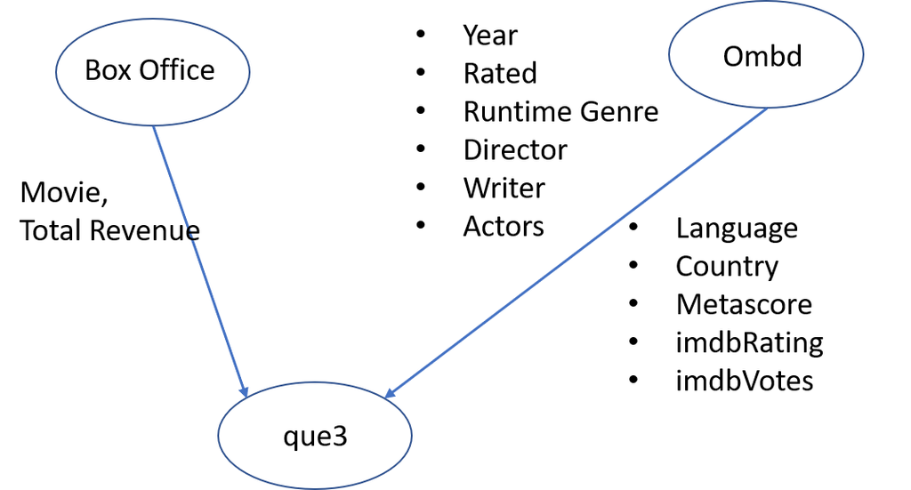

Data looks like this-

|  | movie | total_gross | Critic_Pick | BoxOffice_Hit | Year | Rated | Released | Runtime | Genre | Director | Writer | Actors | Plot | Language | Country | Awards | Metascore | imdbRating | imdbVotes |
| --- | --- | --- | --- | --- | --- | --- | --- | --- | --- | --- | --- | --- | --- | --- | --- | --- | --- | --- | --- |
| 2 | Black Panther | 403613257 | 1 | 1 | 2018 | PG-13 | 16 Feb 2018 | 134 | Action, Adventure, Sci-Fi | Ryan Coogler | Ryan Coogler, Joe Robert Cole, Stan Lee (based on the Marvel comics by), Jack Kirby (based on the Marvel Comics by) | Chadwick Boseman, Michael B. Jordan, Lupita Nyong’o, Danai Gurira | T’Challa, heir to the hidden but advanced kingdom of Wakanda, must step forward to lead his people into a new future and must confront a challenger from his country’s past. | Swahili, Nama, English, Xhosa, Korean | USA, South Africa, South Korea, Australia | 14 nominations. | 88 | 7.4 | 401608 |

### Exploratory Analysis

We will now conduct exploratory data analysis on Box Office Data

| variable | q_zeros | p_zeros | q_na | p_na | q_inf | p_inf | type | unique |
| --- | --- | --- | --- | --- | --- | --- | --- | --- |
| movie | 0 | 0 | 0 | 0.00 | 0 | 0 | factor | 3094 |
| distributor | 0 | 0 | 0 | 0.00 | 0 | 0 | factor | 157 |
| gross | 0 | 0 | 0 | 0.00 | 0 | 0 | numeric | 29155 |
| percent_change | 0 | 0 | 3402 | 10.94 | 0 | 0 | integer | 747 |
| theaters | 0 | 0 | 0 | 0.00 | 0 | 0 | integer | 2426 |
| per_theater | 0 | 0 | 0 | 0.00 | 0 | 0 | integer | 6041 |
| total_gross | 0 | 0 | 0 | 0.00 | 0 | 0 | numeric | 30694 |
| days | 0 | 0 | 0 | 0.00 | 0 | 0 | integer | 10 |
| date | 0 | 0 | 0 | 0.00 | 0 | 0 | factor | 6745 |

Comments -

| variable | mean | std_dev | variation_coef | skewness | kurtosis | range_98 |
| --- | --- | --- | --- | --- | --- | --- |
| total_gross | 2.0e+07 | 3.3e+07 | 1.61 | 4.1 | 29.6 | [5223.27, 168783509.22] |
| gross | 3.2e+06 | 5.7e+06 | 1.80 | 5.4 | 53.2 | [578.18, 26386347.34] |
| theaters | 2.1e+03 | 1.4e+03 | 0.66 | -0.4 | 1.8 | [1, 4256] |
| per_theater | 1.8e+03 | 3.4e+03 | 1.90 | 8.2 | 114.8 | [64.09, 15980.37] |

Comments- (Above metrics are calculated by removing NA values)

### Modelling

#### 1) How well do New York Times (NYT) movie critics pick box office hits?

##### Movie Boxoffice Classification

We use the concept used by “The Numbers” website (as shown in the picture below) to classify the movie as Boxoffice hit or not.

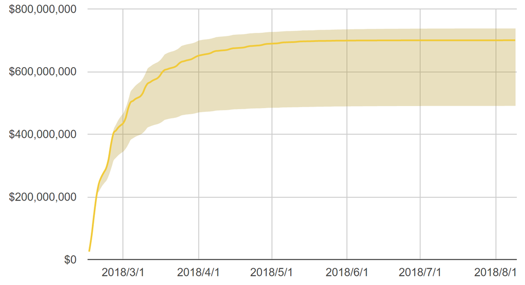

Figure 3: An example from the number website (shaded area represent 95% movie data)

Steps:

1. We will group the data day wise
2. Our next step is to find a region in a plot (total_gross ~ days) where 95% of the movie data exist. We do this by using quantile function.

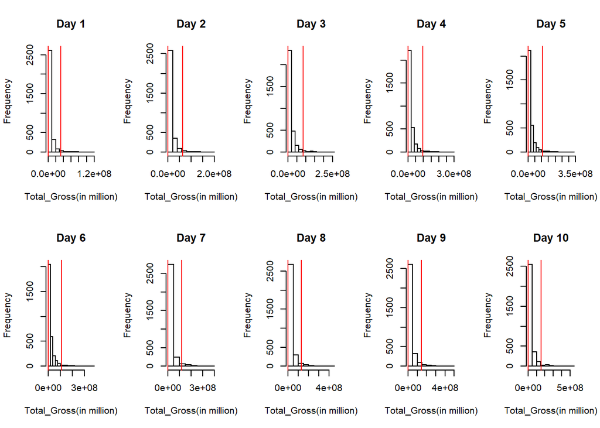

Above plots are histogram plots which are used to find total gross range day wise for 95% of the total movie

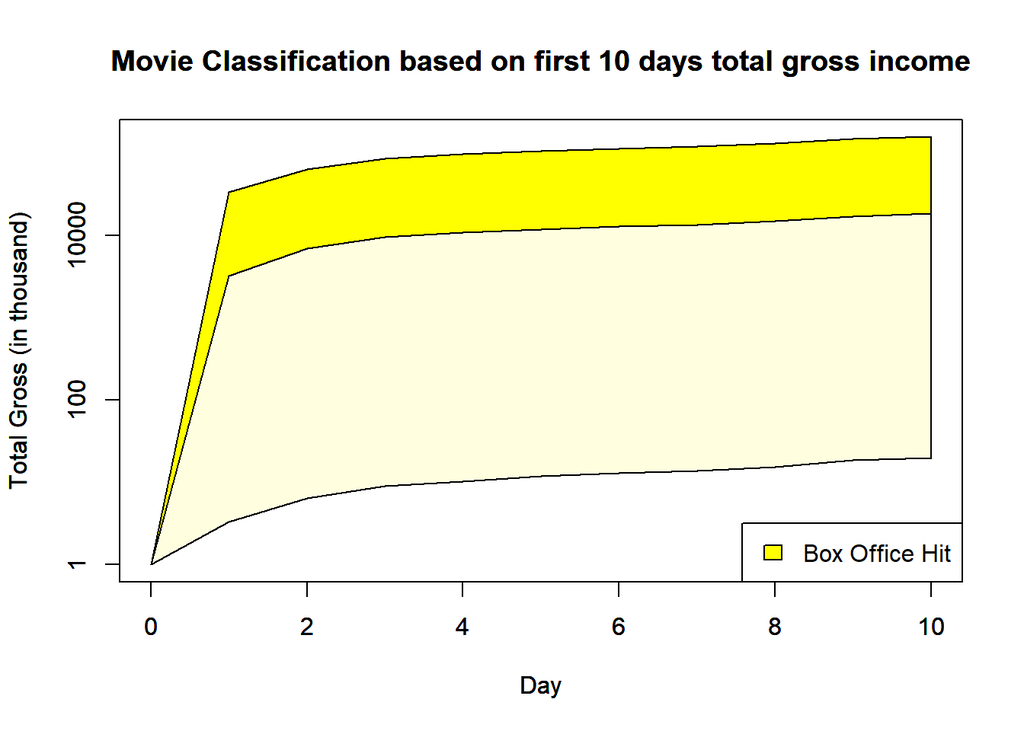

95% of films fall within the shaded area. If a film is in the dark yellow region, it has good legs compared to the average film and can be classifies as boxoffice hit.

(The predictive area is based on movies from the past 18 years)

Movies under consideration

```
## [1] 728
```

We will then classify movie as Boxoffice based on graph found in Exploratory Data Analysis.

We will now find the accuracy of the critic

X = Number of Movies picked up by critics

```
## [1] 117
```

Number of BoxOffice movies

```
## [1] 363
```

Number of Boxoffice movies (out of x)

```
## [1] 49
```

Accuracy

```
## [1] 42
```

Therefore we can say nearly 42% of the movies picked up by the critics were box office hit.

#### 2) Is there a relationship between NYT movie review sentiment and critics picks?

Sementic analysis can be done on the review collected from NYTimes website.

Output would be positive, negative or neutral.

Since, both the variables are categorical

Hence, we can use “Chi-Square test of independence” to check whether two categorical variables from the same population are independent of each other or not.

Crammer’s V can then used later to find correlation that follows from this test.

| movie | Critic_Pick | Review_url | negative | positive | sentiment |
| --- | --- | --- | --- | --- | --- |
| Black Panther | 1 | http://www.nytimes.com/2018/02/06/movies/black-panther-review-movie.html | 40 | 43 | positive |
| The Avengers | 0 | http://www.nytimes.com/2012/05/04/movies/robert-downey-jr-in-the-avengers-directed-by-joss-whedon.html | 46 | 37 | negative |
| Rogue One: A Star Wars Story | 0 | http://www.nytimes.com/2016/12/13/movies/star-wars-rogue-one-review.html | 32 | 25 | negative |
| Iron Man 3 | 0 | http://www.nytimes.com/2013/05/03/movies/iron-man-3-with-robert-downey-jr.html | 53 | 23 | negative |
| Jurassic World: Fallen Kingdom | 0 | http://www.nytimes.com/2018/06/20/movies/jurassic-world-fallen-kingdom-review-chris-pratt.html | 35 | 18 | negative |
| Furious 7 | 0 | http://www.nytimes.com/2015/04/03/movies/review-in-furious-7-a-franchise-continues-to-roar.html | 36 | 29 | positive |

```
##
##     negative neutral positive
##   0      476      17      118
##   1       82       3       32
```

Test the hypothesis whether the picking up of a movie by a critic is independent of movie review at .05 significance level.

```
## Warning in chisq.test(tbl): Chi-squared approximation may be incorrect
```

```
##
##  Pearson's Chi-squared test
##
## data:  tbl
## X-squared = 4, df = 2, p-value = 0.1
```

The warning message found in the solution above is due to the small cell values in the contingency table. To avoid such warning, we consider positive and neutral as positive and again apply chisq.test

```
##   [,1] [,2]
## 0  476  135
## 1   82   35
```

```
##
##  Pearson's Chi-squared test with Yates' continuity correction
##
## data:  ctbl
## X-squared = 3, df = 1, p-value = 0.09
```

The p value 0.0868 is near to the significant level 0.05. Hence, we cannot say with certaninty that these value are independent of each other.

We can apply Crammer’s V test for better understanding of the association.

```
## [1] 0.063
```

Crammer’s V has output value between range 0 to 1.

0 depicting lowest association and 1 being higest.

Since, the output value is low we can say that Movie review has no or very less impact on Critic Pick

#### 3) What characteristics of movies affect revenue?

We will focus on following features to find relationship with movie’s revenue

```
##  [1] "movie"         "total_gross"   "Critic_Pick"   "BoxOffice_Hit"
##  [5] "Year"          "Rated"         "Released"      "Runtime"
##  [9] "Genre"         "Director"      "Writer"        "Actors"
## [13] "Plot"          "Language"      "Country"       "Awards"
## [17] "Metascore"     "imdbRating"    "imdbVotes"
```

Strategy -

For numerical data we will find coorelation coefficient

For categorical value we will find proportion distribution

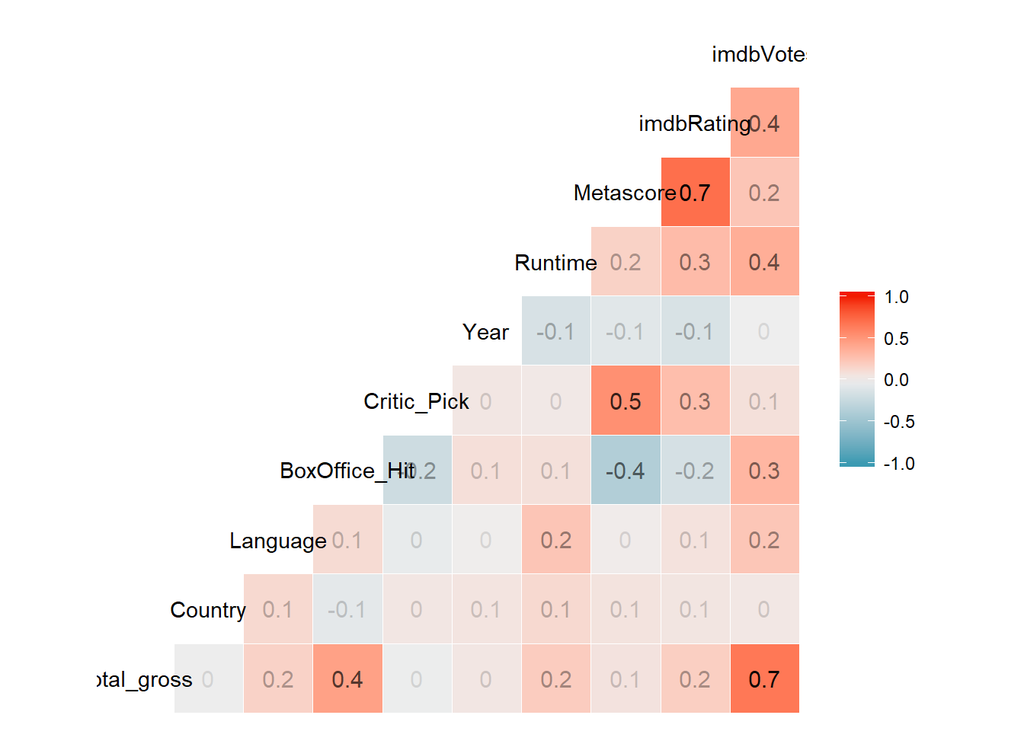

Using above Correlation plot we can say-

1. A high earning movie has higher number of Imdb votes.
2. Box Office Hit movie earns a higher total revenue.
3. Number of Languages, Runtime and imbdRating has a little influence on the Total revenue of the movie.

We further explore the relationship of categorical data with total Revenue

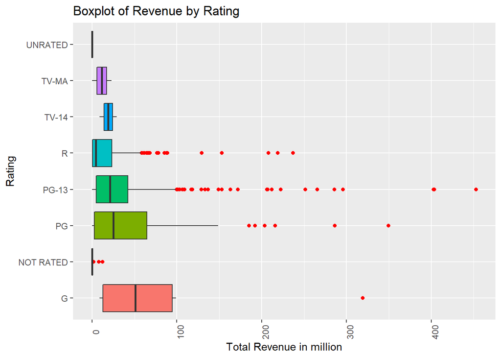

Null Hypothesis : Means of different moving rating are same or we can say Movie Rating does not affect its total Revenue

We now run one-way ANOVA (Analysis Of Variance) test to check the Null Hypothesis

```
##                    Df  Sum Sq Mean Sq F value  Pr(>F)
## rating_data$Rated   7  153517   21931    7.69 6.4e-09 ***
## Residuals         616 1757014    2852
## ---
## Signif. codes:  0 '***' 0.001 '**' 0.01 '*' 0.05 '.' 0.1 ' ' 1
```

(A significance level of 0.05 indicates a 5% risk of concluding that a difference exists when there is no actual difference.)

However, ANOVA does not tells which groups are significantly different from other. Hence, we conduct TurkeyHSD (Tukey Honest Significant Differences) test

```
##   Tukey multiple comparisons of means
##     95% family-wise confidence level
##
## Fit: aov(formula = rating_data$total_gross/1e+06 ~ rating_data$Rated)
##
## $`rating_data$Rated`
##                    diff    lwr   upr p adj
## NOT RATED-G       -88.5 -165.1 -11.9  0.01
## PG-G              -41.0 -109.6  27.7  0.61
## PG-13-G           -47.3 -114.5  19.9  0.39
## R-G               -73.1 -140.1  -6.1  0.02
## TV-14-G           -70.7 -203.4  61.9  0.74
## TV-MA-G           -78.2 -210.9  54.4  0.62
## UNRATED-G         -89.7 -265.2  85.7  0.78
## PG-NOT RATED       47.5    5.3  89.7  0.02
## PG-13-NOT RATED    41.2    1.4  81.0  0.04
## R-NOT RATED        15.4  -24.1  54.9  0.94
## TV-14-NOT RATED    17.7 -103.3 138.8  1.00
## TV-MA-NOT RATED    10.3 -110.8 131.3  1.00
## UNRATED-NOT RATED  -1.2 -168.1 165.7  1.00
## PG-13-PG           -6.3  -27.1  14.5  0.98
## R-PG              -32.1  -52.2 -12.0  0.00
## TV-14-PG          -29.8 -146.0  86.4  0.99
## TV-MA-PG          -37.3 -153.5  79.0  0.98
## UNRATED-PG        -48.7 -212.1 114.7  0.99
## R-PG-13           -25.8  -40.3 -11.3  0.00
## TV-14-PG-13       -23.5 -138.8  91.9  1.00
## TV-MA-PG-13       -31.0 -146.3  84.4  0.99
## UNRATED-PG-13     -42.4 -205.2 120.4  0.99
## TV-14-R             2.3 -112.9 117.6  1.00
## TV-MA-R            -5.2 -120.4 110.1  1.00
## UNRATED-R         -16.6 -179.3 146.1  1.00
## TV-MA-TV-14        -7.5 -169.9 154.9  1.00
## UNRATED-TV-14     -19.0 -217.9 180.0  1.00
## UNRATED-TV-MA     -11.5 -210.4 187.5  1.00
```

How to interpret above values -

1. diff: difference between means of the two groups
2. lwr, upr: the lower and the upper end point of the confidence interval at 95% (default)
3. p adj: p-value after adjustment for the multiple comparisons.
4. If the adjusted p value is less than 0.05, then the group has a signifant difference.

For example:

1. There is no significance difference in total movie revinue( in million) between PG and G (P=0.61>0.05), Pg-13 and G (P=0.39>0.05). Similarly, the following groups have no significant difference.

```
##                    diff p adj
## PG-G              -41.0  0.61
## PG-13-G           -47.3  0.39
## TV-14-G           -70.7  0.74
## TV-MA-G           -78.2  0.62
## UNRATED-G         -89.7  0.78
## UNRATED-NOT RATED  -1.2  1.00
## PG-13-PG           -6.3  0.98
## TV-14-PG          -29.8  0.99
## TV-MA-PG          -37.3  0.98
## UNRATED-PG        -48.7  0.99
## TV-14-PG-13       -23.5  1.00
## TV-MA-PG-13       -31.0  0.99
## UNRATED-PG-13     -42.4  0.99
## TV-MA-R            -5.2  1.00
## UNRATED-R         -16.6  1.00
## TV-MA-TV-14        -7.5  1.00
## UNRATED-TV-14     -19.0  1.00
## UNRATED-TV-MA     -11.5  1.00
```

2. PG and PG-13 movies generates more revenue as compared to NOT RATED

```
##                 diff p adj
## PG-NOT RATED      48 0.015
## PG-13-NOT RATED   41 0.036
```

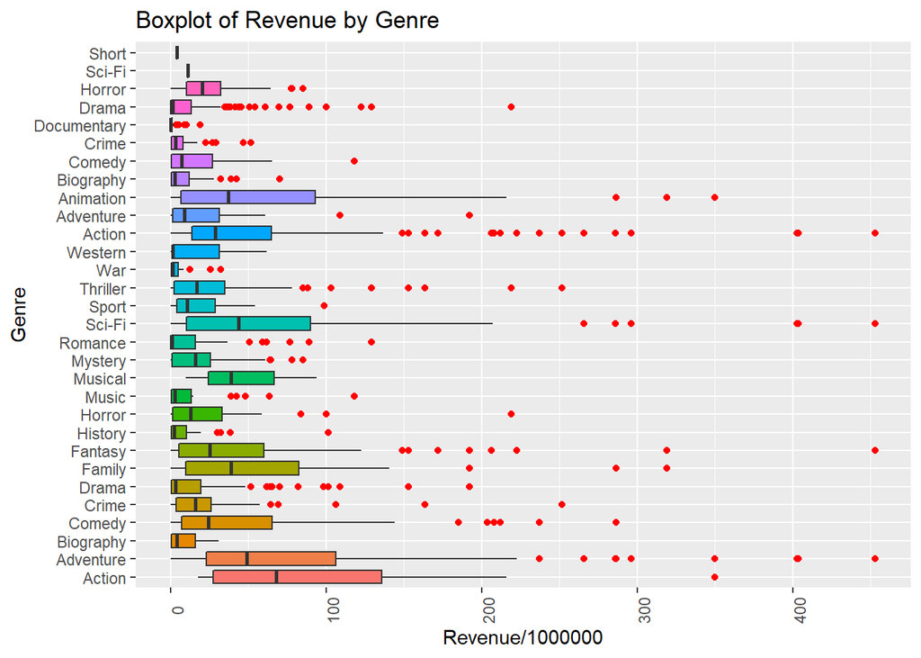

Null Hypothesis : Means of different moving Genere are same or we can say Movie Genere does not affect its total Revenue

We now run ANOVA test to check the Null Hypothesis

```
##                    Df  Sum Sq Mean Sq F value Pr(>F)
## genre_data$Genre   29 1104633   38091    13.7 <2e-16 ***
## Residuals        1765 4904774    2779
## ---
## Signif. codes:  0 '***' 0.001 '**' 0.01 '*' 0.05 '.' 0.1 ' ' 1
```

F value is 13.71 and p-value is very low. Hence, we can reject Null hypothesis.

Similar to previously used strategy we now conduct POST HOC TEST

Conclusion:

```
##                      diff   p adj
##  Sci-Fi- Biography     68 1.5e-03
## Animation- Biography   58 3.6e-02
##  Sci-Fi- Crime         53 1.6e-06
## Action- Crime          34 1.1e-03
## Animation- Crime       42 2.2e-03
##  Family- Drama         47 1.9e-04
##  Fantasy- Drama        41 2.2e-05
##  Sci-Fi- Drama         64 7.9e-12
## Action- Drama          45 7.9e-12
## Animation- Drama       53 1.1e-08
##  Sci-Fi- History       68 4.8e-07
## Action- History        49 2.4e-04
## Animation- History     57 2.3e-04
##  Sci-Fi- Horror        51 2.7e-03
##  Sci-Fi- Music         61 1.5e-03
##  Sci-Fi- Mystery       58 4.0e-07
## Action- Mystery        39 2.7e-04
## Animation- Mystery     47 5.8e-04
##  Sci-Fi- Romance       66 2.4e-11
## Action- Romance        47 4.2e-09
## Animation- Romance     55 4.7e-07
## Action- Thriller       30 1.2e-03
## Animation- Thriller    38 4.2e-03
## Action- War            53 8.2e-03
## Animation- War         61 3.6e-03
```

By looking at the box plot and above data we can say

1. Sci-Fi movies earns more revenue as compared to (Biography,Crime,Drama,History,Horror,Music,Mystery,Romance)
2. Animation movies earns more revenue as compared to (Biography,Crime,Drama,History,Mystery,Romance,Thriller,War)
3. Action movies earns more revenue as compared to (Crime,Drama,History,Mystery,Romance,Thriller,War)
4. Family movies earns more revenue as compared to Drama
5. Fantasy movies earns more revenue as compared to Drama

We can also find which all Directors, actors and writers have movies with higest average revenue.

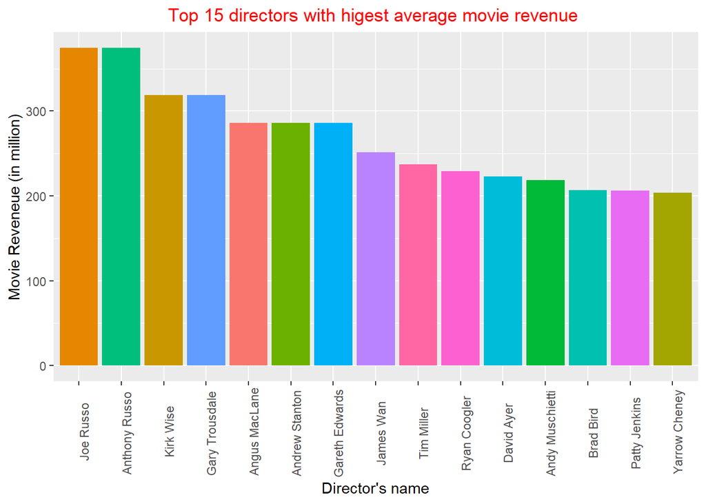

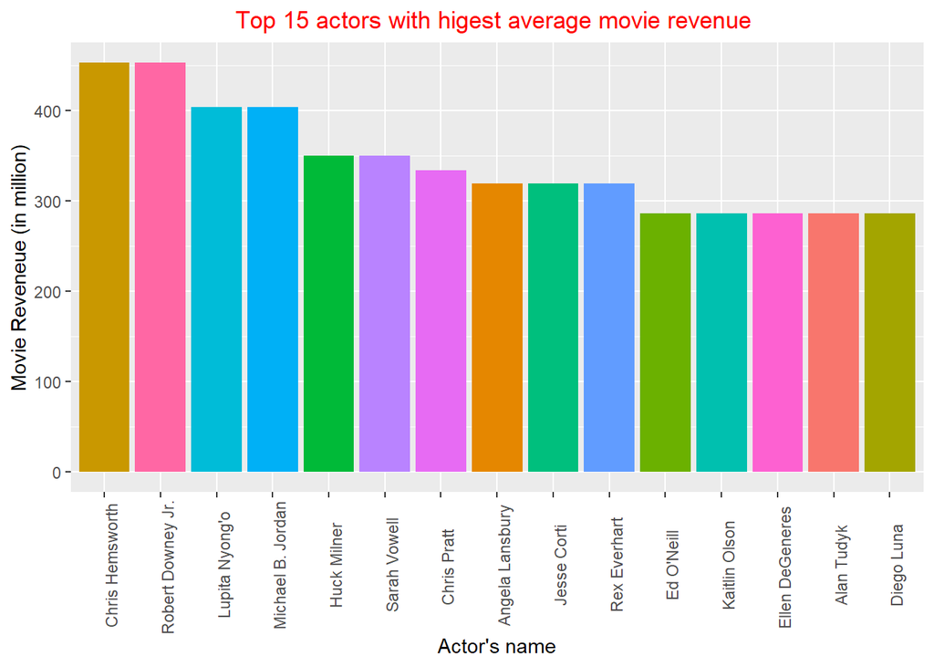

[figure not shown]

These plot doesn’t carry much significance as frequency of each data point is very less